Name - Mohd Naushad Shakir  
Student ID - R00183525

# Spam Email detection using Supervised Classification Machine Learning models.

### Introduction

This report was prepared to analysed and create a supervised classification machine learning models to classify emails as spam or non-spam from the dataset.The dataset used for this assignment is the Enron email dataset.

#### Import the necessary packages and libraries

```python
#installed and loaded all the necessary libraries.
from sklearn.utils import shuffle  #to shuffle the dataset
from collections import defaultdict #to map default values to a list in dictionary
from pathlib import Path #for importing the dataset
from nltk.corpus import stopwords #for removing the stopwords
from sklearn.model_selection import train_test_split #for spliting the data into train and test
from nltk.stem import PorterStemmer  #for stemming
from nltk.tokenize import word_tokenize #for tokenization
from collections import Counter #for unique value in a dictionary
from functools import reduce
from sklearn.feature_extraction.text import TfidfVectorizer #for tf-idf feature extraction
from sklearn.naive_bayes import MultinomialNB # multinomial naive bayes
from sklearn.tree import DecisionTreeClassifier #decision tree model
from sklearn.ensemble import RandomForestClassifier #random forest model
from sklearn.svm import SVC  #support vector machine model
from sklearn.metrics import classification_report,confusion_matrix,accuracy_score
from sklearn.model_selection import RandomizedSearchCV #for tuning the hyper parameter
from sklearn import metrics
from scipy.stats import reciprocal, uniform
import pickle # for saving the model to disk
import operator
import matplotlib.pyplot as plt #for plotting the graph
import string
import pandas as pd
import numpy as np
```

#### Import the dataset:

Created a function "**import_dataset** to import the ham and spam emails and stored it in pandas dataframe.It takes two arguments (dir_path and label) where dir_path is the directory path of ham and spam emails respectively and label denotes whether it is ham email or spam email ('0' denotes ham email while '1' denotes spam email).  
This function also create a new column **status** and assigned a value '0' for ham and '1' for spam emails.

```python
#function for importing the dataset
def import_dataset(dir_path,label):
    my_dir_path = dir_path
    mail = defaultdict(list)
    if label == 0:
        for file in Path(my_dir_path).iterdir():
            with open(file,"r") as file_open:
                mail["file_name"] = file.name
                mail["text"].append(file_open.read())
    if label == 1:
        for file in Path(my_dir_path).iterdir():
            with open(file,"r",encoding = "latin-1") as file_open:
                mail["file_name"] = file.name
                mail["text"].append(file_open.read())
    df = pd.DataFrame(mail)
    df.drop("file_name", axis=1, inplace=True)
    df.rename(columns={'text': 'mail'}, inplace=True)
    if label == 0:
        df['status'] = 0
    if label == 1:
        df['status'] = 1
    return df
```

Used the **import_dataset** function created above to import ham and spam and passed directory path and label for ham/spam emails respectively ('0' is for ham and '1' is for spam).

```python
#import the dataset into ham and spam pandas dataframe using import_dataset function created above
ham = import_dataset("D:/Sem-2/Machine Learning/Assig/enron1/ham",0)
spam = import_dataset("D:/Sem-2/Machine Learning/Assig/enron1/spam",1)
```

Since ham and spam emails are imported in different pandas dataframe(ham and spam).Therefore both the dataframe were combined into one single pandas dataframe (**all_mail**).  
Thereafter dimensions for the combined dataset were checked.

```python
#merge ham and spam dataframe and displaying its size
all_mail = pd.concat([ham, spam])
print("The dimensions of the combined dataset",all_mail.shape)
```

```
The dimensions of the combined dataset (5172, 2)
```

It was observed that the all_mail dataset contains 5172 emails in total.  
Thereafter it was checked it contains how many ham and spam emails.

```python
#to show number of ham and spam emails
all_mail.groupby('status').describe()
```

| status | mail count | mail unique | mail top | mail freq |
| --- | --- | --- | --- | --- |
| 0 | 3672 | 3531 | Subject: calpine daily gas nomination\n>\nrick... | 20 |
| 1 | 1500 | 1463 | Subject: \n | 16 |

It was observed that it contains 3672 ham emails and 1500 spam emails.  
It was also observed that it contains some duplicate emails as number of unique ham emails are 3531 and unique spam emails are 1463 so it was required to drop the duplicate emails.

#### Drop duplicate emails.

```python
#to drop duplicate emails
all_mail.drop_duplicates(inplace = True)
print("The dimensions of the dataset after dropping duplicate emails",all_mail.shape)
```

```
The dimensions of the dataset after dropping duplicate emails (4994, 2)
```

After dropping of the duplicate emails the dataset contains only 4994 emails out of which 3531 are ham emails and 1463 are spam emails.So there was 178 duplicate emails in the original dataset.

#### Checked for NULL/empty rows(emails)

```python
#to check for NULL values(emails)
all_mail.isnull().sum()
```

```
mail      0
status    0
dtype: int64
```

It was observed that there was no NULL or empty rows(emails).

#### Shuffle the dataset

It was required to shuffle the dataset so that when the dataset was divided into training and test dataset,it should not be biased.

```python
#to shuffle the dataset and display first  rows
all_mail = shuffle(all_mail)
all_mail.head()
```

|  | mail | status |
| --- | --- | --- |
| 1092 | Subject: republic royalty 5 / 00\nthis deal wa... | 0 |
| 307 | Subject: change in operating companies\nplease... | 0 |
| 1449 | Subject: sparkasse security issue\nsehr geehrt... | 1 |
| 1058 | Subject: 10 stuff better than v i a g r a\nhey... | 1 |
| 495 | Subject: vlc , 0 dln for sale , no prior pres ... | 1 |

By looking at the first five rows it was observed that the dataset is now shuffled and it contains two column,one column 'mail' which contains the body of the emails and second column 'status' which denotes whether it is ham or spam email.

### Data Preprocessing

Created a function **process_message** which will take an email and preprocessed it.It will perform the below operations:

1. Received an email as an argument.
2. Convert all the text into **lowercase**.
3. **Tokenization** : It involves splitting up a message into pieces and Removing all the **punctuation marks**.
4. Removed **stopwords** from the email.Stopwords are the words which does not give much meaning to a sentence and they can be removed without affecting the meaning of the sentence.
5. Peform **Stemming** of the emails.It will cut off the end or the beginning of the word, and will take into consideration a list of common prefix and suffix that were observed in an inflected word.

```python
#function for preprocessing the emails
def process_message(mail):
    clean_mail = " "
    mail = mail.lower() #convert emails to lowercase
    nopunc =[char for char in mail if char not in string.punctuation]  #remove punctuation marks
    nopunc=''.join(nopunc)
    clean_word = [word for word in nopunc.split() if word.lower() not in stopwords.words('english')] #remove stopwords
    clean_word = [w for w in clean_word if len(w) > 2]
    ps = PorterStemmer() #perform stemming
    clean_word = [ps.stem(word) for word in clean_word]
    for i in range(len(clean_word)):
        clean_mail = clean_mail + " "+ clean_word[i]
    return clean_mail
```

Thereafter all the email were preprocess at once by using the function **'process_message'** created above.

```python
#preprocess all the emails using function created above
all_mail["mail"]=all_mail['mail'].apply(process_message)
all_mail.head()
```

|  | mail | status |
| --- | --- | --- |
| 1092 | subject republ royalti deal termin nelson fe... | 0 |
| 307 | subject chang oper compani pleas oper compan... | 0 |
| 1449 | subject sparkass secur issu sehr geehrt kund... | 1 |
| 1058 | subject stuff better heya found websit cheap... | 1 |
| 495 | subject vlc dln sale prior pre crip tion nee... | 1 |

By looking at the first 5 rows it was observed that all emails have been pre-processed now.

## Train Test Split

With the help of 'train_test_split' module availaible in sklearn library,the dataset was divided into training and test set by 70:30 ratio.Training set contains 70% of the data while test set containd 30% of the data.  
The training feature will be stored in mail_train and the training target will be stored in status_train.  
The testing feature will be stored in mail_test and the testing target will be stored in status_test .

```python
#divide the dataset into train and test (70:30) ratio
mail_train,mail_test,status_train,status_test = train_test_split(all_mail['mail'],all_mail['status'],test_size=0.3)
```

#### Statistics of the training and testing dataset.

Thereafter there was a need to find out the number of ham and spam emails in training and testing dataset.But since training dataset is divided into training feature(mail_train) and training target(status_train) and testing dataset is divided into testing feature (mail_test) and the testing target (status_test). So just for collecting the statistics, feature and target sets of the training and test datasets were combined into 'train_data' and 'test_data' pandas dataframe.  
A function **'combine_Dataset'** was created to merge the feature and target set into training and test dataset.

```python
#function to combine the dataset
def combine_Dataset(mail,status):
    dataset = pd.concat([mail,status],axis = 1)
    return dataset
```

Used **'combine_dataset'** function created above to get the train and test dataset in order to get useful statistics from them.

```python
#combine train and test dataset
train_data = combine_Dataset(mail_train,status_train)
test_data = combine_Dataset(mail_test,status_test)
```

```python
#to show the number ham and spam emails in train dataset
train_data['status'].value_counts()
```

```
0    2456
1    1039
Name: status, dtype: int64
```

It was observed that training data contains 2456 ham emails and 1039 spam emails.

```python
#to show the number ham and spam emails in test dataset
test_data['status'].value_counts()
```

```
0    1075
1     424
Name: status, dtype: int64
```

It was observed that testing data contains 1075 ham emails and 424 spam emails.

### EDA on training dataset.

Used the **training section** of the dataset to perform some exploratory data analysis. EDA was done to become accustomed with the data and gain insights into the kinds of features may be useful for classification.Dataset 'train_data' created above contains both the feature and target set of training dataset so it was used for EDA.  
First a new column 'length' is created which contains the email length of respective email.

```python
#create a new column containing the lenght of respective emails
train_data['length']=train_data['mail'].apply(len)
train_data.head()
```

|  | mail | status | length |
| --- | --- | --- | --- |
| 2267 | subject hpl nom decemb 2000 see attach file ... | 0 | 71 |
| 158 | subject document pleas read attach file | 1 | 41 |
| 1527 | subject lone star point daren sever point li... | 0 | 385 |
| 614 | subject network cabl tester free crimp strip... | 1 | 1386 |
| 157 | subject best choic free onlin prescript fede... | 1 | 756 |

In order to find out the length and top 20 words used in ham and spam emails, we required separate dataset containing only ham and spam emails respectively.So two subset (ham_mail,spam_mail) was created for this purpose.

```python
#create subset of ham and spam emails from train dataset
ham_mail = train_data[train_data['status'] == 0]
spam_mail = train_data[train_data['status'] == 1]
```

A function **'top_words'** was created in order to find out the top 20 words for ham and spam emails respectively.  
This function will receive all the emails as arguments,convert it into a list then tokenize it.After that it will create a dictionary with word as the **key** and frequency of that word as the **value**.At the end it will return the top 20 words with their respective frequency.

```python
#create a function to return the 20 topwords from the emails
def top_words(mails):
    words = mails['mail'].tolist()
    token = [word_tokenize(x) for x in words]
    words = reduce(operator.concat,token)
    top_words = dict(Counter(words).most_common(20))
    return top_words
```

Thereafter function **'top_words'** created above was used to get the top 20 words for **ham emails** and plot a bar graph using 'matplotlib' library.

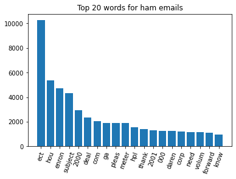

```python
#plot the top 20 words of ham emails
words = top_words(ham_mail)
plt.bar(range(len(words)), list(words.values()), align='center')
plt.xticks(range(len(words)), list(words.keys()))
plt.xticks(rotation = 70)
plt.title("Top 20 words for ham emails")
plt.show()
```

Next bar graph was plotted for top 20 words for **spam emails'**

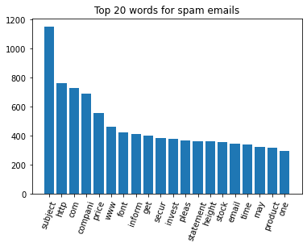

```python
#plot the top 20 words for spam emails
words = top_words(spam_mail)
plt.bar(range(len(words)), list(words.values()), align='center')
plt.xticks(range(len(words)), list(words.keys()))
plt.xticks(rotation = 70)
plt.title("Top 20 words for spam emails")
plt.show()
```

Thereafter the email lengths distribution was compared in spam and spam emails using histogram and boxplot.  
The statistics was email length for both ham and spam emails were found out.

```python
#to show statistics of ham emails
ham_mail.length.describe()
```

```
count     2456.000000
mean       547.744707
std        832.937940
min         21.000000
25%        134.000000
50%        285.000000
75%        663.000000
max      19735.000000
Name: length, dtype: float64
```

```python
#to show statistics of spam emails
spam_mail.length.describe()
```

```
count     1039.000000
mean       797.519731
std       1274.928405
min          9.000000
25%        177.500000
50%        359.000000
75%        776.000000
max      19432.000000
Name: length, dtype: float64
```

Below are the observation on comparing the lengths distribution of ham and spam emails:

1. The maximum lenght of a ham email is 19735 while for spam is 19432.
2. The minimum lenght of a ham email is 21 while for spam is 9.
3. The average lenght of a ham email is 547 while for spam is 797.  
   On comparing the average lenth, it was observed that **spam email is generally longer than ham email.**  
   Thereafter a histogram and boxplot was plotted for email length for ham and spam emails.

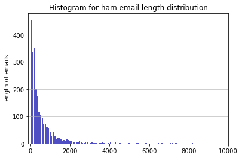

```python
#plot histogram for emails length for ham emails
data = ham_mail['length']
plt.hist(x=data, bins='auto', color='#0504aa',
                            alpha=0.7, rwidth=0.85)
plt.grid(axis='y', alpha=0.75)
plt.xlim(-100,10000)
plt.ylabel('Length of emails')
plt.title('Histogram for ham email length distribution')
plt.show()
```

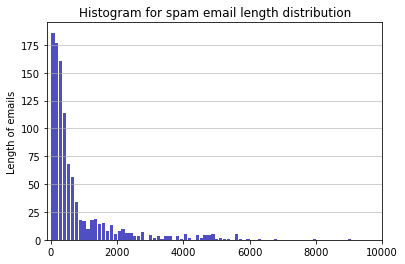

```python
#plot histogram for emails length for spam emails
data = spam_mail['length']
plt.hist(x=data, bins='auto', color='#0504aa',
                            alpha=0.7, rwidth=0.85)
plt.grid(axis='y', alpha=0.75)
plt.xlim(-100,10000)
plt.ylabel('Length of emails')
plt.title('Histogram for spam email length distribution')
plt.show()
```

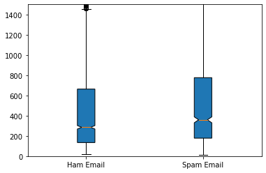

```python
#plot boxplot for emails length for ham and spam emails
data = [ham_mail['length'], spam_mail['length']]
plt.boxplot(data,patch_artist=True,labels=['Ham Email','Spam Email'],notch='True')
plt.ylim(0,1500)
plt.show()
```

It was observed that training (feature,target) and testing (feature,target) dataset were in series object so they were converted into dataframe.

```python
#converted train and test data to dataframe format
mail_train = mail_train.to_frame()
status_train = status_train.to_frame()
mail_test = mail_test.to_frame()
status_test = status_test.to_frame()
```

Before proceeding to feature extraction and model selection/evaluation we need a validation dataset so **Training dataset** was further divided into training and validation dataset in (80:20) ratio.Now the new training dataset will consist of first 80% of dataset while validation dataset will consist of last 20% of the dataset.  
Original training dataset contains total 3495 emails,so in order to divide it into 80:20 ratio,first 2796(first 80%) of rows were taken in new training dataset while 699(last 20%) rows were taken in validation dataset.

```python
#create training and validation dataset from train dataset
training_set_mail = mail_train[:2796]
training_set_status = status_train[:2796]
validation_set_mail = mail_train[-699:]
validation_set_status = status_train[-699:]
```

## Feature extraction (tf-idf)

Tf-idf was used for feature extraction.Tf-idf stands for term frequency-inverse document frequency.The tf-idf weight is a weight used in information retrieval and text mining.The tf-idf weight is composed of two terms: the first computes the normalized Term Frequency (TF) means the number of times a word appears in a document, divided by the total number of words in that document.  
**TF(t) = (Number of times term t appears in a document) / (Total number of terms in the document)**  
The second term is the Inverse Document Frequency (IDF), computed as the logarithm of the number of the documents in the corpus divided by the number of documents where the specific term appears.  
**IDF(t) = log_e(Total number of documents / Number of documents with term t in it)**  
Tf-idf was applied on training,validation and testing dataset accordingly.

```python
#using tf-idf perform feature extraction on training,validation and testing dataset
tfvec = TfidfVectorizer()
tfidf_training = tfvec.fit_transform(training_set_mail['mail'])
tfidf_validation = tfvec.transform(validation_set_mail['mail'])
tfidf_test = tfvec.transform(mail_test['mail'])
```

Next a function **model_execution** was created to execute the passed model.It takes a model,hyper Parameter,training dataset,target dataset and validation dataset as arguments.It used the **RandomizedSearchCV for tuning the hyper Parameter**.Then it fit the passed model into training and target dataset. After that values are predicted by applying the trained model on **validation dataset**.  
**These predicted values for validation dataset and the model are then return from function**.

```python
#create function for tuning the hyperParameter,fitting the model on training dataset and predicting on validation dataset
def model_execution(model,hyperParameter,tfidf_training,training_set_status,tfidf_validation):
    classifier_tuned = RandomizedSearchCV(model,hyperParameter)
    classifier_tuned.fit(tfidf_training, training_set_status.values.ravel())
    pred = classifier_tuned.predict(tfidf_validation)
    return pred,classifier_tuned
```

Next a function **model_evaluation** was created to evaluate the model.It take validation set and predicted values as arguments.It prints the confusion matrix and return the accuracy for the model.

```python
#create function for evaluating the model on validation dataset and printing Confusion matrix and accuracy
def model_evaluation(validation_set,pred):
    print("Confusion Matrix")
    print(confusion_matrix(validation_set,pred))
    print("")
    accuracy =accuracy_score(validation_set,pred)
    return(accuracy)
```

Next a function **metric** was created to investigate the kinds of errors for the model.It take validation set and predicted values as arguments. It will give the Mean Absolute Error,Mean Squared Error and Root Mean Squared Error for the model.

```python
#create a function to investigate kinds of errors using sklearn_metrics
def metric(validation_set_status,pred):
    print('Mean Absolute Error:', metrics.mean_absolute_error(validation_set_status,pred))
    print('Mean Squared Error:', metrics.mean_squared_error(validation_set_status,pred))
    print('Root Mean Squared Error:', np.sqrt(metrics.mean_squared_error(validation_set_status,pred)))
```

Next a function **save_model_to_disk** was created to save the model to disk using pickle module. It takes model and filename as arguments and save the model to disk.

```python
#create a function which uses pickle module to save model to disk
def save_model_to_disk(model,filename):
    pickle.dump(model, open(filename, 'wb'))
```

## Multinomial Naive Bayes

The first model that was used is Multinomial Naive Bayes.Different parameters and their values was taken into acount before fitting and evaluating the model.Below HyperParameter were considered for tuning for Multinomial Naive Bayes.  
**alpha** : Additive (Laplace/Lidstone) smoothing parameter (0 for no smoothing).  
**fit_prior** : Whether to learn class prior probabilities or not. If false, a uniform prior will be used.  
Then model accuracy was determined by applying the model on the validation dataset.  
Then metric function was utilised to investigate the kinds of errors for the model.  
Then model was saved to file "MultinomialNB_Classifier.sav" to disk using function 'save_model_to_disk' created above.

```python
#defining hyperParamter and creating/evaluating the Multinomial Naive Bayes model
hyperParameter = {'alpha': np.linspace(0.5, 1.5, 6),'fit_prior': [True, False]}
model = MultinomialNB()
pred_MNB,modelMNB = model_execution(model,hyperParameter,tfidf_training,training_set_status,tfidf_validation)
accuracyMNB = model_evaluation(validation_set_status,pred_MNB)
print("The accuracy of Multinomial Naive Bayes model is",accuracyMNB)
print(" ")
metric(validation_set_status,pred_MNB)
save_model_to_disk(modelMNB,"MultinomialNB_Classifier.sav")
```

```
Confusion Matrix
[[491   2]
 [ 15 191]]

The accuracy of Multinomial Naive Bayes model is 0.9756795422031473

Mean Absolute Error: 0.024320457796852647
Mean Squared Error: 0.024320457796852647
Root Mean Squared Error: 0.15595017729022512
```

## Decision Tree Model

The next model that was used is Decision Tree.Different parameters and their values was taken into acount before fitting and evaluating the model.Below HyperParameter were considered for tuning for Decision tree model. **max_depth** : This indicates how deep the tree can be. The deeper the tree, the more splits it has and it captures more information about the data.  
**min_samples_split** : It indicates the minimum number of samples required to split an internal node.  
**max_features** : It indicates the number of features to consider when looking for the best split.  
Then model accuracy was determined by applying the model on the validation dataset.  
Then metric function was utilised to investigate the kinds of errors for the model.  
Then model was saved to file "Decision_Tree_Classifier.sav" to disk using function 'save_model_to_disk' created above.

```python
#defining hyperParamter and creating/evaluating the Decision Tree model
hyperParameter = {"max_depth": np.linspace(1, 32, 32, endpoint=True),
                  "min_samples_split": np.linspace(0.1, 1.0, 5, endpoint=True),
              "max_features": list(range(1,100))
              }
model = DecisionTreeClassifier()
pred_DT,modelDT = model_execution(model,hyperParameter,tfidf_training,training_set_status,tfidf_validation)
accuracyDT = model_evaluation(validation_set_status,pred_DT)
print("The accuracy of Decision Tree model is",accuracyDT)
print(" ")
metric(validation_set_status,pred_DT)
save_model_to_disk(modelDT,"Decision_Tree_Classifier.sav")
```

```
Confusion Matrix
[[481  12]
 [137  69]]

The accuracy of Decision Tree model is 0.7868383404864091

Mean Absolute Error: 0.21316165951359084
Mean Squared Error: 0.21316165951359084
Root Mean Squared Error: 0.46169433558750844
```

## Random Forest Model

The next model that was used is Random Forest Model.Different parameters and their values was taken into acount before fitting and evaluating the model.Below HyperParameter were considered for tuning for Random Forest Model.  
**n_estimators** : It indicates the number of trees in the forest.  
**bootstrap** : It represent the method for sampling data points.  
**max_depth** : It indicates the maximum number of levels in each decision tree.  
**min_samples_leaf** : It indicates minimum number of data points allowed in a leaf node.  
**min_samples_split** : It indicates the minimum number of data points placed in a node before the node is split.  
**max_features** : It indicates the maximum number of features taken into account for splitting a node.  
Next model accuracy was determined by applying the model on the validation dataset.  
Next metric function was utilised to investigate the kinds of errors for the model.  
Next model was saved to file "Random_Forest_Classifier.sav" to disk using function 'save_model_to_disk' created above.

```python
#defining hyperParamter and creating/evaluating the Random Forest model
hyperParameter = {'n_estimators': [200, 400, 600],
                 'bootstrap': [True, False],
                 'max_depth': [10, 20,None],
                 'max_features': ['auto', 'sqrt'],
                 'min_samples_leaf': [2, 4],
                 'min_samples_split': [5, 10]
                 }
model = RandomForestClassifier()
pred_RF,modelRF = model_execution(model,hyperParameter,tfidf_training,training_set_status,tfidf_validation)
accuracyRF = model_evaluation(validation_set_status,pred_RF)
print("The accuracy of Random Forest model is",accuracyRF)
print(" ")
metric(validation_set_status,pred_RF)
save_model_to_disk(modelRF,"Random_Forest_Classifier.sav")
```

```
Confusion Matrix
[[487   6]
 [  9 197]]

The accuracy of Random Forest model is 0.9785407725321889

Mean Absolute Error: 0.02145922746781116
Mean Squared Error: 0.02145922746781116
Root Mean Squared Error: 0.1464896838272619
```

## Support Vector Machine Model

The next model that was used is Support Vector Machine.Different parameters and their values was taken into acount before fitting and evaluating the model.Below HyperParameter were considered for tuning for Support Vector Machine.  
**C** : Regularization parameter. The strength of the regularization is inversely proportional to C.  
**gamma** : Kernel coefficient for ‘rbf’, ‘poly’ and ‘sigmoid’.  
**kernel** : Specifies the kernel type to be used in the algorithm.  
**shrinking** : Whether to use the shrinking heuristic.  
**probability** : This must be enabled prior to calling fit, will slow down that method as it internally uses 5-fold cross-validation.  
**degree** : Degree of the polynomial kernel function (‘poly’). Ignored by all other kernels.  
Then model accuracy was determined by applying the model on the validation dataset.  
Then metric function was utilised to investigate the kinds of errors for the model.  
Then model was saved to file "Support_Vector_Machine_Classifier.sav" to disk using function 'save_model_to_disk' created above.

```python
#defining hyperParamter and creating/evaluating the Support Vector Machine model
hyperParameter = {'C': uniform(1, 10),
              'gamma': reciprocal(0.001, 0.1),
              'kernel': ['rbf'],
              'shrinking': [True,False],
              'probability':[True,False],
              'degree':[2,3,4]}
model = SVC()
pred_SVC,modelSVC = model_execution(model,hyperParameter,tfidf_training,training_set_status,tfidf_validation)
accuracySVC = model_evaluation(validation_set_status,pred_SVC)
print("The accuracy of Support Vector Machine model is",accuracySVC)
print(" ")
metric(validation_set_status,pred_SVC)
save_model_to_disk(modelSVC,"Support_Vector_Machine_Classifier.sav")
```

```
Confusion Matrix
[[489   4]
 [  1 205]]

The accuracy of Support Vector Machine model is 0.9928469241773963

Mean Absolute Error: 0.00715307582260372
Mean Squared Error: 0.00715307582260372
Root Mean Squared Error: 0.08457585839117283
```

## Model Selection

In total 4 models were used to train the training dataset and were subsequently evaluated on validation dataset.These 4 models are Multinomial Naive Bayes,Decision Tree,Random Forest and Support Vector Machine.The accuracy for the model when applied on validation dataset is as follows:  
Multinomial Naive Bayes : 97.56  
Decision Tree : 78.68  
Random Forest : 97.85  
Support Vector Machine : 99.28  
It was clear that Support Vector Machine have the highest accuracy among all the models.So Support Vector classifier was then applied to testing dataset.

## Model Evaluation

Since Support Vector Machine have the highest accuracy,it is applied to testing dataset and its accuracy was determined.

```
Confusion Matrix for testing dataset
[[1059   16]
 [   3  421]]

The accuracy of the Support Vector Machine Model for testing dataset is  0.9873248832555037

Mean Absolute Error: 0.012675116744496331
Mean Squared Error: 0.012675116744496331
Root Mean Squared Error: 0.11258382097129378
```

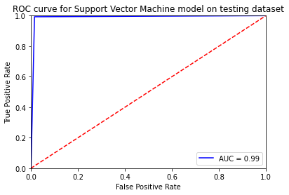

```python
#evaluating the Support Vector Machine model on testing dataset
pred = modelSVC.predict(tfidf_test)
print("Confusion Matrix for testing dataset")
print(confusion_matrix(status_test,pred))
print("")
print("The accuracy of the Support Vector Machine Model for testing dataset is ",accuracy_score(status_test,pred))
print("")
metric(status_test,pred)
fpr, tpr, threshold = metrics.roc_curve(status_test,pred)
roc_auc = metrics.auc(fpr, tpr)
plt.title('ROC curve for Support Vector Machine model on testing dataset')
plt.plot(fpr, tpr, 'b', label = 'AUC = %0.2f' % roc_auc)
plt.legend(loc = 'lower right')
plt.plot([0, 1], [0, 1],'r--')
plt.xlim([0, 1])
plt.ylim([0, 1])
plt.ylabel('True Positive Rate')
plt.xlabel('False Positive Rate')
plt.show()
```

## Summary

From this assignment it was observed that SVM algorithm works best for spam emails detection on this dataset.It may not be the case in the real world scenario as in real world the dataset size will be quite large as compared to this 'enron' dataset.

#### References

1. https://towardsdatascience.com/spam-classifier-in-python-from-scratch-27a98ddd8e73
2. https://medium.com/@randerson112358/email-spam-detection-using-python-machine-learning-abe38c889855
3. https://www.codeproject.com/Articles/1232758/Detect-E-mail-Spam-Using-Python